# Data visualization with ggplot2

Wasilios Hariskos

23 December 2020

# Load packages

```r
# install.packages("ggplot2")
library(ggplot2) # for data visualization
library(gapminder) # dataset
library(dplyr) # for data tranformation
```

# A scatterplot with five dimensions

## Prepare data

```r
gapminder_1997 <- gapminder %>%
  filter(year == 1997)

glimpse(gapminder_1997)
```

```
## Observations: 142
## Variables: 6
## $ country   <fct> Afghanistan, Albania, Algeria, Angola, Argentina, Au...
## $ continent <fct> Asia, Europe, Africa, Africa, Americas, Oceania, Eur...
## $ year      <int> 1997, 1997, 1997, 1997, 1997, 1997, 1997, 1997, 1997...
## $ lifeExp   <dbl> 41.763, 72.950, 69.152, 40.963, 73.275, 78.830, 77.5...
## $ pop       <int> 22227415, 3428038, 29072015, 9875024, 36203463, 1856...
## $ gdpPercap <dbl> 635.3414, 3193.0546, 4797.2951, 2277.1409, 10967.282...
```

## Create a new ggplot object, …

- specify gapminder_1997 as input data frame,
- add a point geom,
- map `gdpPercap` to `x` aesthetic,
- map `lifeExp` to `y` aesthetic

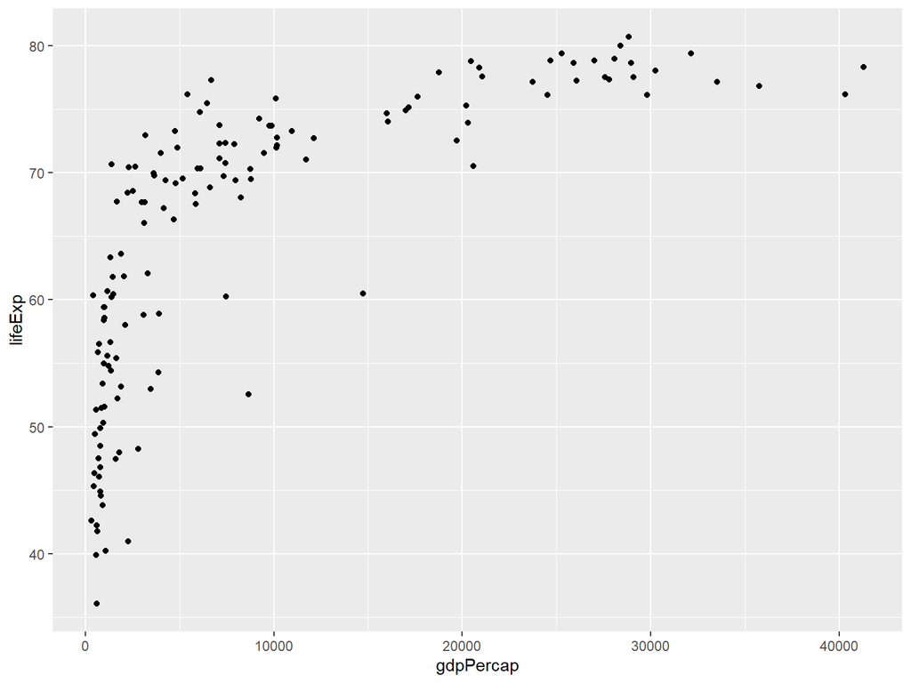

```r
ggplot(data = gapminder_1997) +
  geom_point(mapping = aes(x = gdpPercap,
                           y = lifeExp))
```

## Change the scale of x-axis to log10

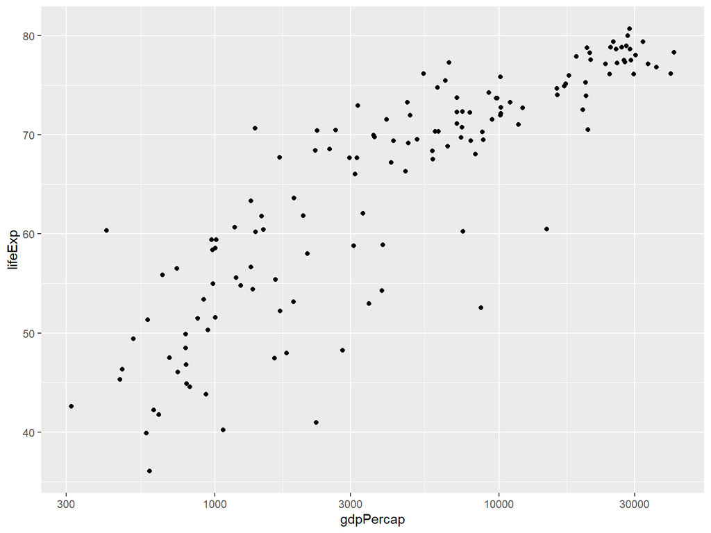

```r
ggplot(data = gapminder_1997) +
  geom_point(mapping = aes(x = gdpPercap,
                           y = lifeExp)) +
  scale_x_log10()
```

On a logarithmic 10 scale each unit on the x-axis $(b - a)$ represents a change of 10 times $a$, i.e. $b = a \cdot 10$. As a result, the observations with a `gdpPercap` smaller than $10000$ are less crowded.

```r
(x <- c(10, 100, 1000, 10000, 100000))
```

```
## [1] 1e+01 1e+02 1e+03 1e+04 1e+05
```

```r
log10(x) # puts elements of x equidistant (labels of x remain)
```

```
## [1] 1 2 3 4 5
```

## Map continent to color aesthetic

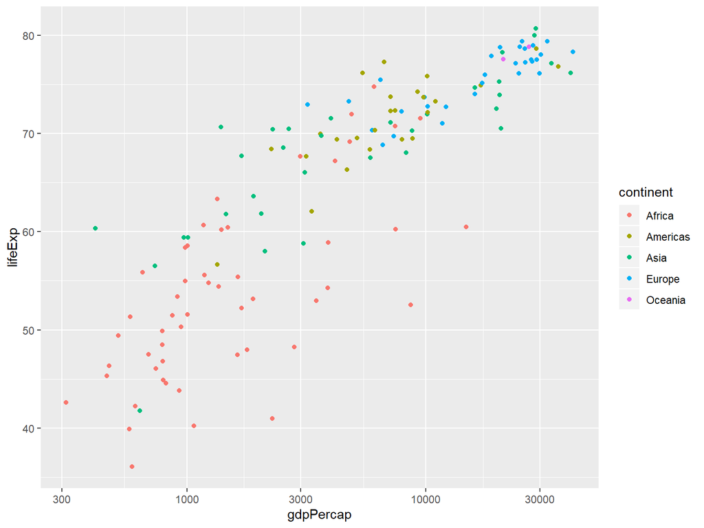

```r
ggplot(data = gapminder_1997) +
  geom_point(mapping = aes(x = gdpPercap,
                           y = lifeExp,
                           color = continent)) +
  scale_x_log10()
```

The aesthetic `color` works well with a categorical variable such as `continent`. Notice that a legend is added that indicates the mapping between aesthetic `color` and variable `continent`. We see that the red colored African countries tend to have the lowest `gdpPercap` while the opposite is true for the blue colored European countries.

## Map population to size aesthetic

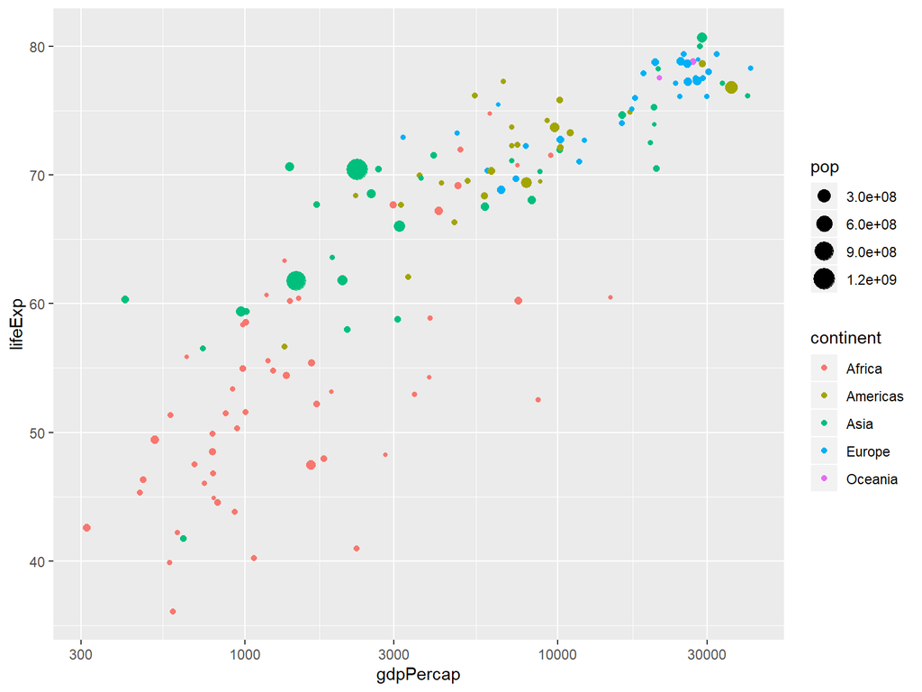

```r
ggplot(data = gapminder_1997) +
  geom_point(mapping = aes(x = gdpPercap,
                           y = lifeExp,
                           color = continent,
                           size = pop)) +
  scale_x_log10()
```

The aesthetic `size` works well with numeric variables such as `pop`. Here, countries with higher population get larger points. Notice that a legend with scientific notation is added: `1.2e+09` is equal to a population of $1.2 \cdot 10^9$ or 1.2 billion.

## Use faceting to compare development accross years

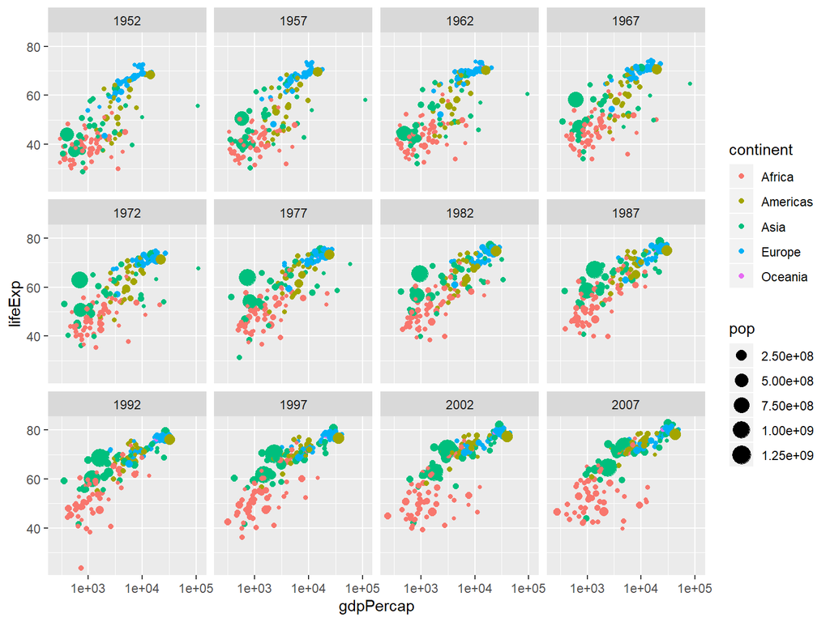

```r
ggplot(data = gapminder) +
  geom_point(mapping = aes(x = gdpPercap,
                           y = lifeExp,
                           color = continent,
                           size = pop)) +
  scale_x_log10() +
  facet_wrap(facets = ~ year,
             nrow = 3)
```

The function `facet_wrap()` divides the plot into subplots, with each subplot representing a different year. The formula `facets = ~ year` means `by year`.

## Summary

- We used function `ggplot()` to create a ggplot object.
- We declared the input data frame to be a filtered dataset `gapminder_1997` that contains only observations from 1997.
- We created a scatterplot with function `geom_point()`
- We mapped the variables `gdpPercap` and `lifeExp` to the `x` and `y` aesthetics.
- We changed the x-axis scale to a log scale with function `scale_x_log10()` so that we can see the observations with low `gdpPercap` better.
- We mapped two more variables `continent` and `pop` to the `color` and `size` aesthetics.
- Lastly, we used the full `gapminder` dataset and added the fifth dimension `year` to divide the plot into facets (subplots) with function `facet_wrap()`.

# Line plots for visualizing change over time

## Scatterplot vs. line plot

So far we used only scatterplots. The scatterplot is most useful for displaying the relationship between two continuous variables. Each point on a scatterplot represents one observation.

Let’s look at some code chunks that we used to create a scatterplot (see last section of the dplyr slides on data transformation).

```r
by_continent_year <- gapminder %>%
  group_by(continent, year) %>%
  summarize(meanLifeExp = mean(lifeExp),
            medianLifeExp = median(lifeExp),
            minGdpPercap = min(gdpPercap),
            maxGdpT = max((gdpPercap * pop)/1e12),
            totalPopB = sum(pop/1e9))
```

We constructed the following scatterplot:

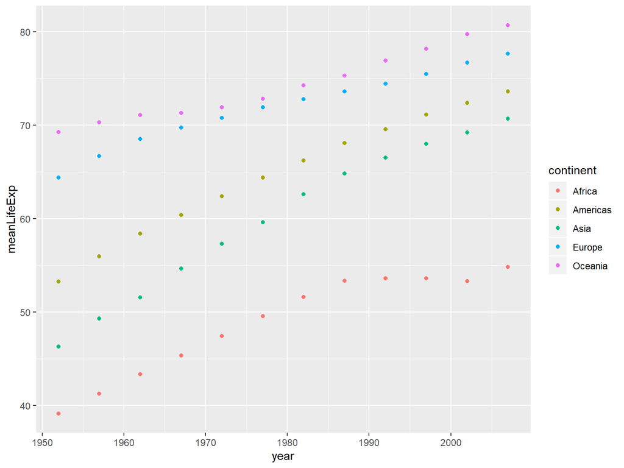

```r
ggplot(data = by_continent_year) +
  geom_point(mapping = aes(x = year,
                           y = meanLifeExp,
                           color = continent))
```

Since, we look at a change over time, we change the type of plot from `geom_point` to `geom_line()` to connect the observations between years.

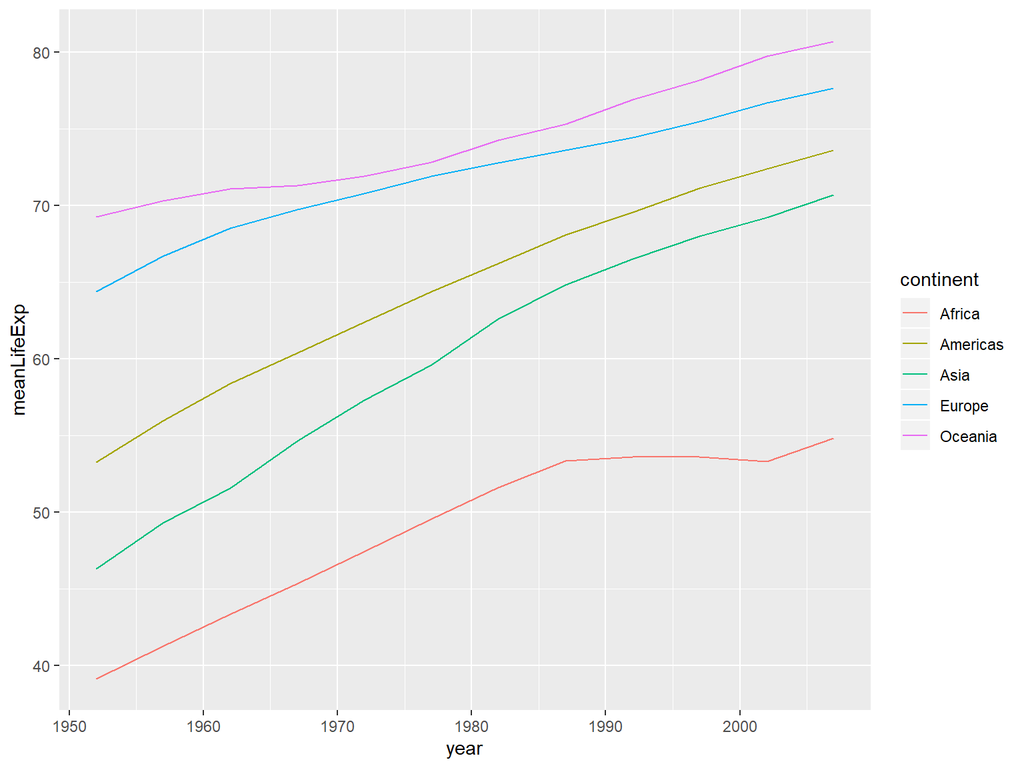

```r
ggplot(data = by_continent_year) +
  geom_line(mapping = aes(x = year,
                          y = meanLifeExp,
                          color = continent))
```

## Line plot showing the change in meanGdpPercap over time

```r
by_year <- gapminder %>%
  group_by(year) %>%
  summarize(meanGdpPercap =  mean(gdpPercap))
```

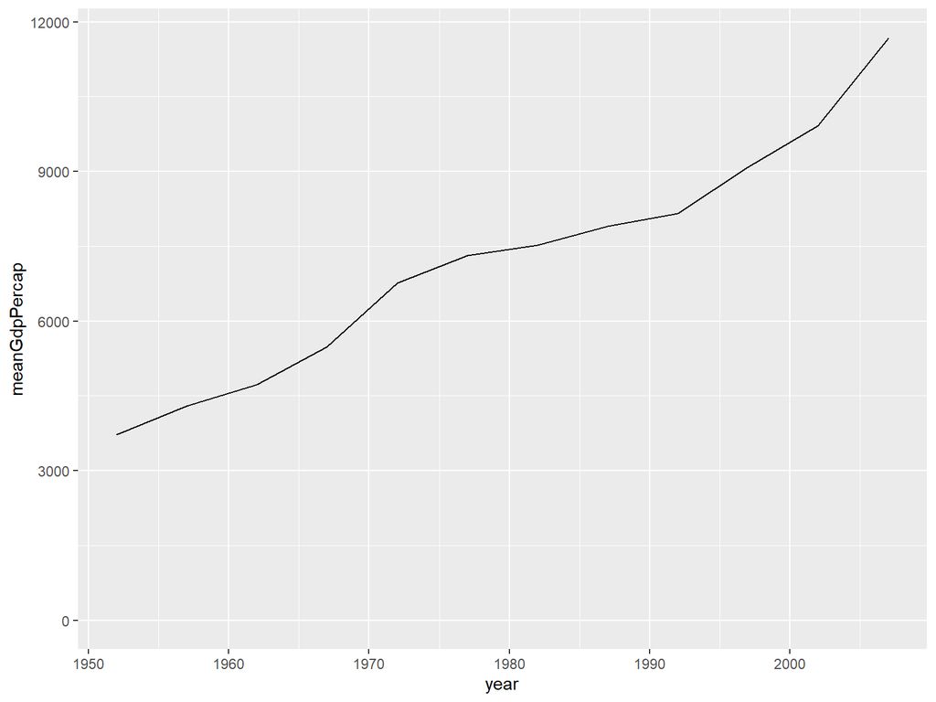

```r
ggplot(data = by_year) +
  geom_line(mapping = aes(x = year, y = meanGdpPercap)) +
  expand_limits(y = 0)
```

```r
by_year_continent <- gapminder %>%
  group_by(year, continent) %>%
  summarize(meanGdpPercap =  mean(gdpPercap))
```

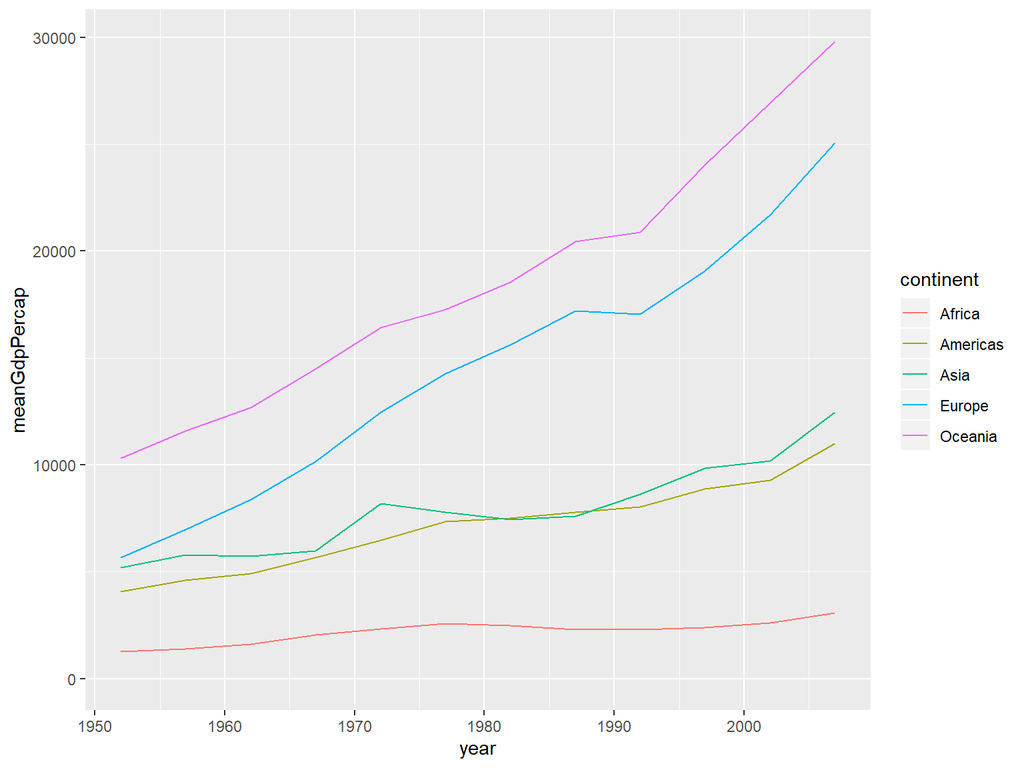

```r
ggplot(data = by_year_continent) +
  geom_line(mapping = aes(x = year,
                          y = meanGdpPercap,
                          color = continent)) +
  expand_limits(y = 0)
```

# Bar plots for comparing statistics among several categories

```r
europe1997 <- gapminder %>%
  filter(year == 1997,
         continent == "Europe",
         pop > 50e6)

europe1997
```

```
## # A tibble: 5 x 6
##   country        continent  year lifeExp      pop gdpPercap
##   <fct>          <fct>     <int>   <dbl>    <int>     <dbl>
## 1 France         Europe     1997    78.6 58623428    25890.
## 2 Germany        Europe     1997    77.3 82011073    27789.
## 3 Italy          Europe     1997    78.8 57479469    24675.
## 4 Turkey         Europe     1997    68.8 63047647     6601.
## 5 United Kingdom Europe     1997    77.2 58808266    26075.
```

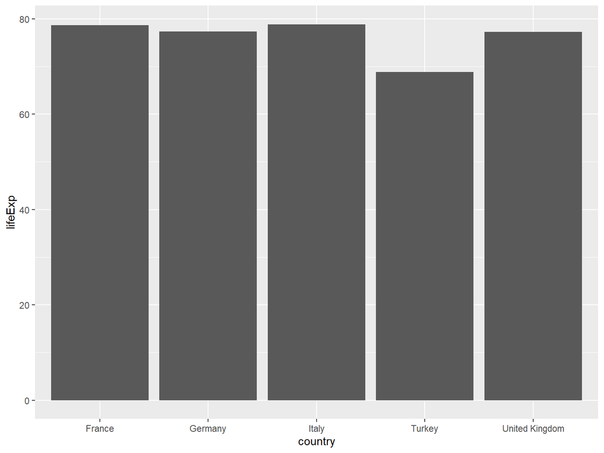

```r
ggplot(data = europe1997) +
geom_col(mapping = aes(x = country,
                       y = lifeExp))
```

# Histograms for describing the distribution of a numeric variable

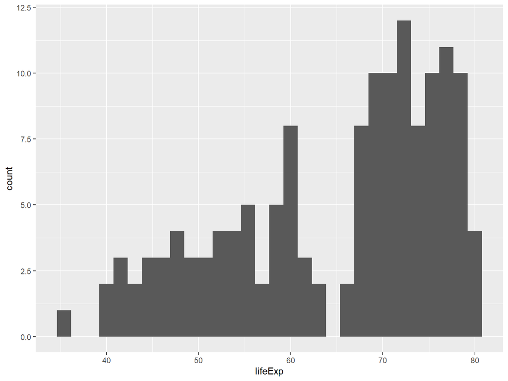

```r
ggplot(data = gapminder_1997) +
  geom_histogram(mapping = aes(x = lifeExp))
```

Adjust the bin width to 5 years with argument `binwidth`. Which information do you gain if the `fill` aesthetic is set to `continent`?

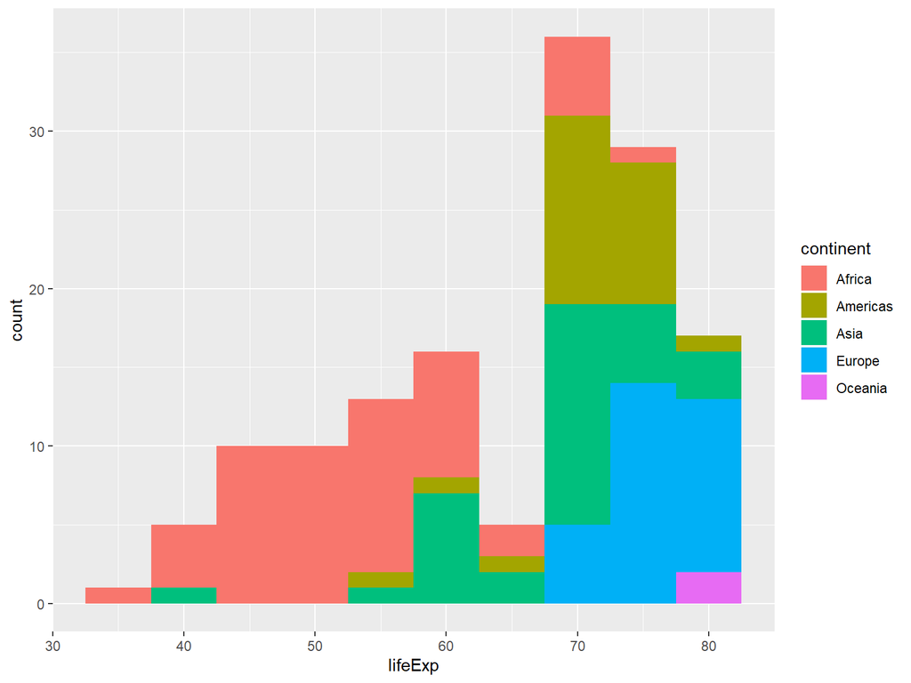

```r
ggplot(data = gapminder_1997) +
  geom_histogram(mapping = aes(x = lifeExp,
                               fill = continent),
                 binwidth = 5)
```

# Boxplots for comparing distributions of a numeric variable among several categories

## The distribution of lifeExp by continent

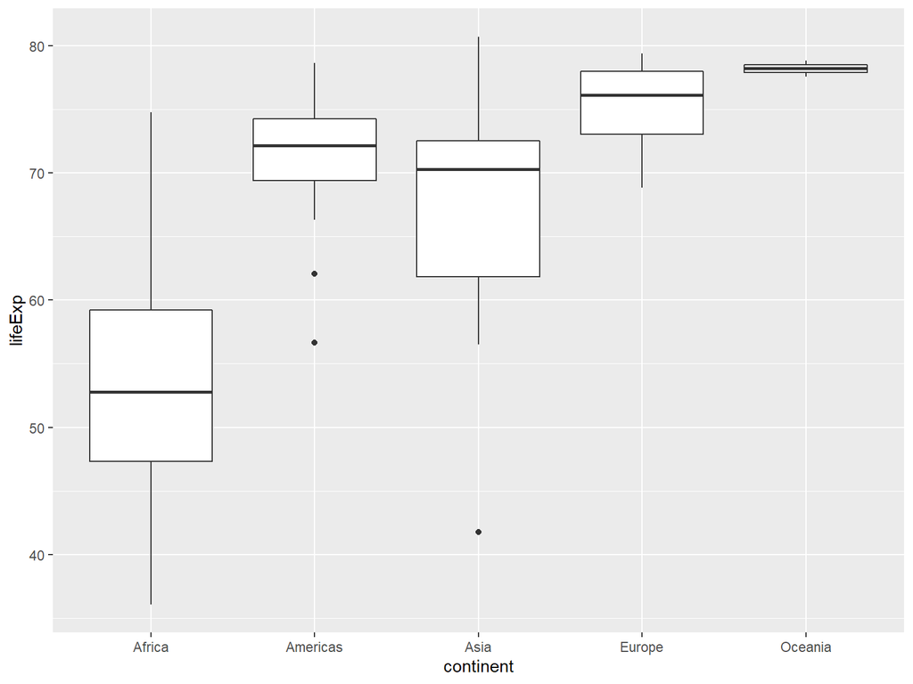

```r
ggplot(data = gapminder_1997) +
  geom_boxplot(mapping = aes(x = continent,
                             y = lifeExp))
```

The boxplot visualizes all “outlying” points individually and five summary statistics:

- horizontal line: the median of the distribution
- lower (upper) box called hinge: 1st (3rd) quartile or 25th (75th) percentile
- lower (upper) vertical line called whisker: extends from the hinge to the smallest (largest) value no further than $1.5 \cdot IQR$,

where $IQR$ is the inter-quartile range or the distance between the 1st and 3rd quartiles. See `?geom_boxplot` for more information.

## The distribution of gdpPercap by continent

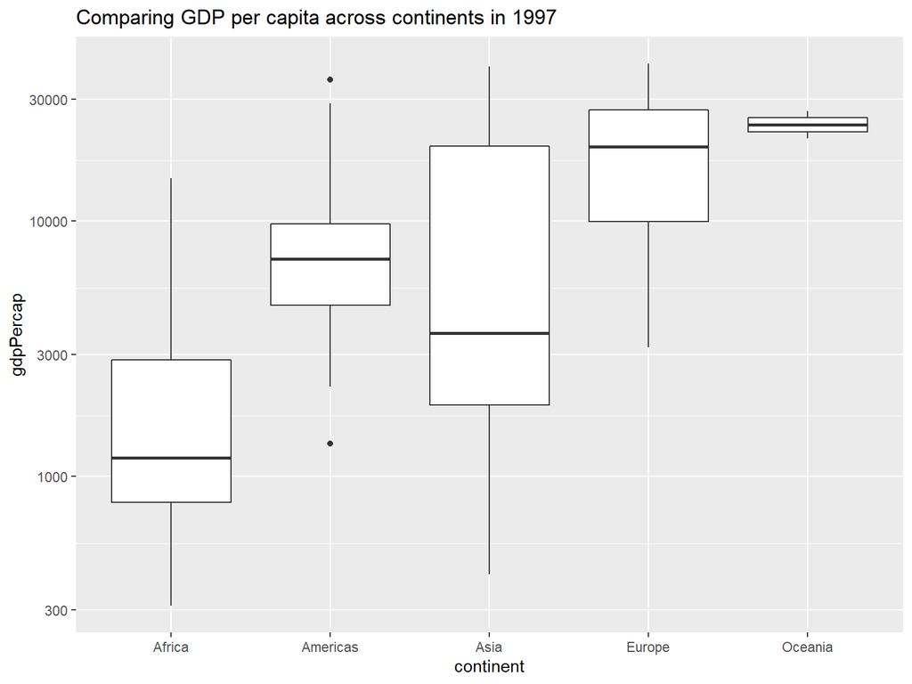

```r
ggplot(data = gapminder_1997) +
  geom_boxplot(mapping = aes(x = continent,
                             y = gdpPercap)) +
  scale_y_log10() +
  ggtitle(label = "Comparing GDP per capita across continents in 1997")
```